# Simulation plot

Yichen

5/19/2020

## Simulation 1

### Parameters

- 3 legacy trials and 3 future trials (n = 400 each)
- For each trial: 1 unobserved causal factor with coefficient $\beta$
- Outcome $y = \beta x + \epsilon$
- $Q$ **potentially** correlated features
- $q$ **truly** correlated features with correlation $\rho$ (randomly selected)
- 15 noise features
- **Outcomes**
  - Oracle $R^2$ when causal factor is not observed
  - Generalized $R^2$
  - Estimated generalized $R^2$ with 10-fold cross-validation
  - Estimated generalized $R^2$ with leave-one-study-out cross-validation

### Result 1a

- **Hypothesis: As number of truly correlated features $q$ increases, the correlated features picked up by the legacy model are more likely to overlap with correlated features in the future trials, which leads to smaller difference between generalized $R^2$ and estimated generalized $\hat R^2$**
- Fix Q, as q increase, generalized $R^2$ and two $\hat R^2$ all increase towards the oracle $R^2$. The difference between generalized $R^2$ and $\hat R^2$ decreases as we have a larger proportion of candidate correlated features among candidate correlated features.
- While $\hat R^2$ from 10-fold cv largely overestimates the generalized $R^2$, $\hat R^2$ from loo cv corrects this gap and does a better job at estimating the generalized $R^2$.

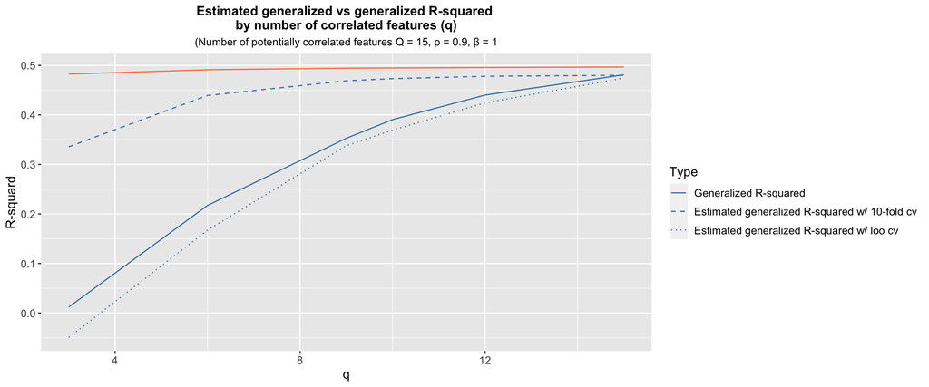

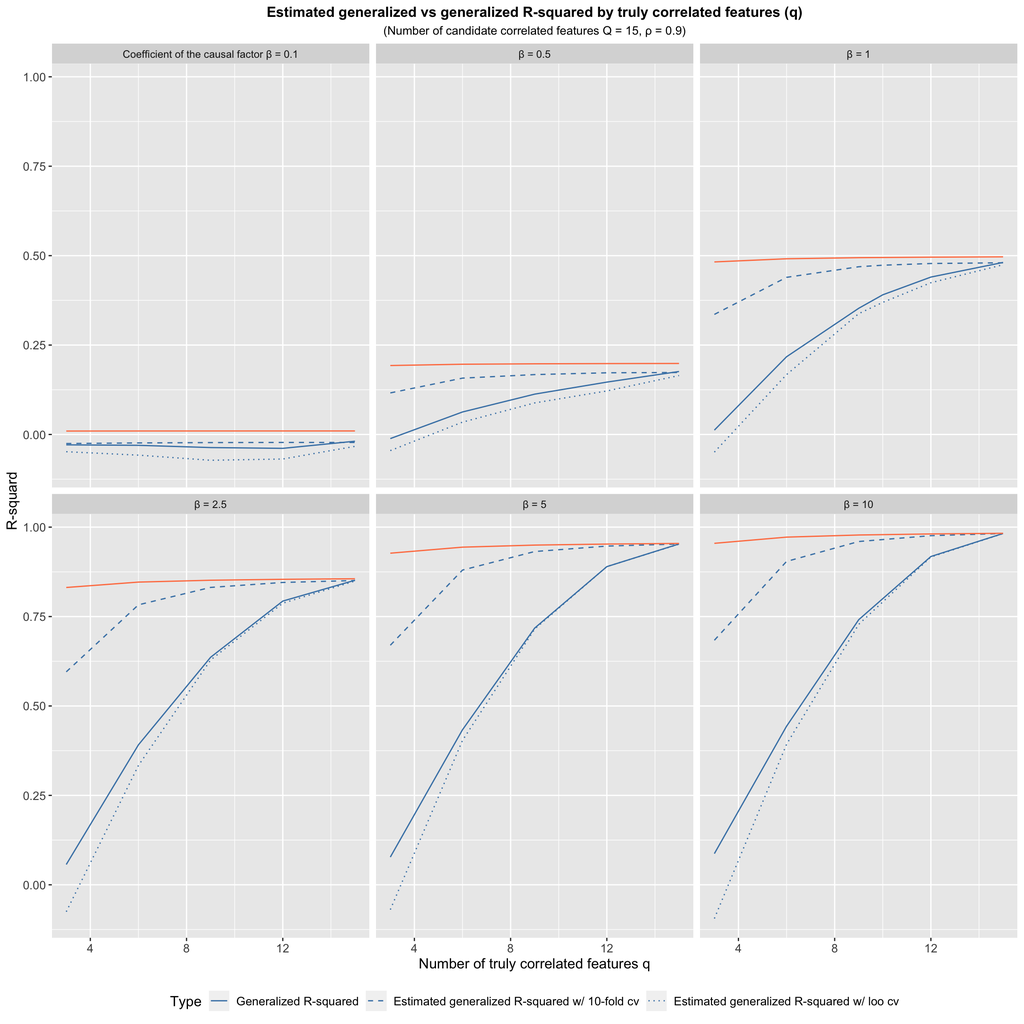

### Result 1b

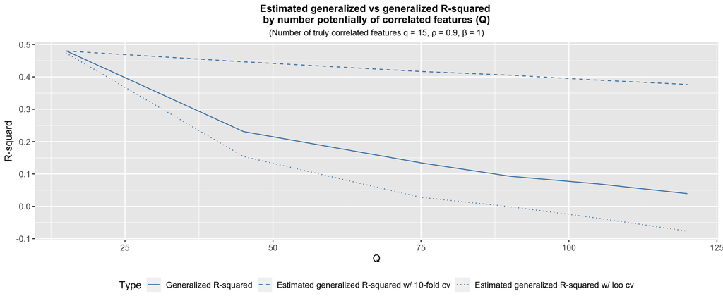

## Simulation 2

- Updated simulation:
  - 3 legacy trials and 1 future trial (n = 600 each)
    - 40 potentially correlated features (a.1 - a.40)
    - legacy trial 1: a.1 - a.10 are truly correlated
    - legacy trial 2: a.11 - a.20 are truly correlated
    - legacy trial 3: a.11 - a.30 are truly correlated
    - *future trial: a.31 - a.40 are truly correlated*

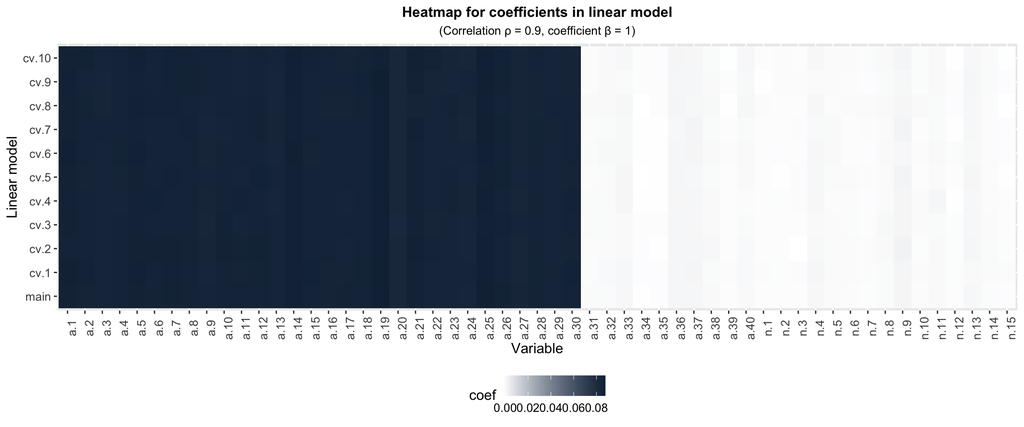

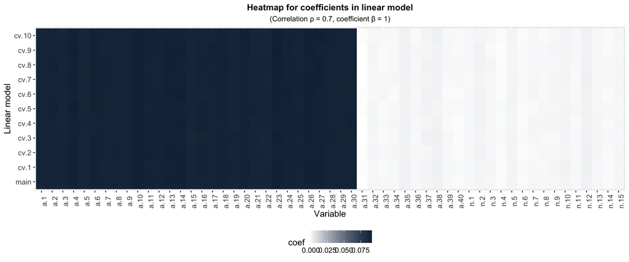

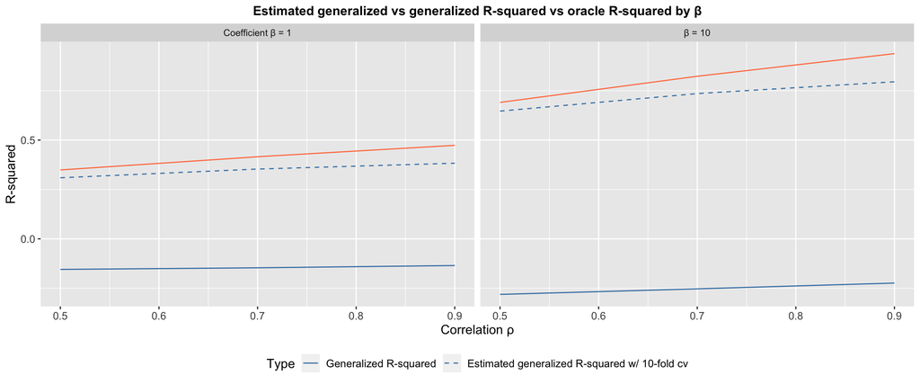

## Simulation 3

- *Updated simulation:*
- 3 legacy trials and 1000 future trial (n = 400 each)
- Predict on each future trial
- Result: As $\frac{q}{Q}$ increases, the variance of the generalized $R^2$ decreases

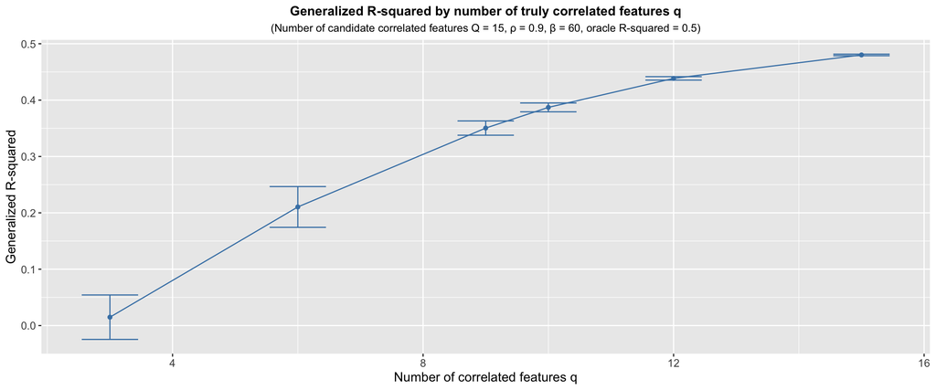

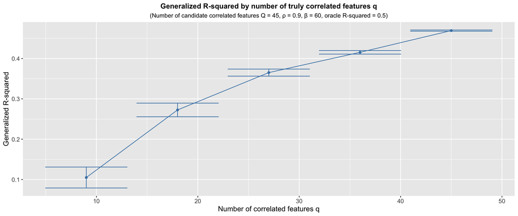

## Calculation

- Generalized $R^2$: $R^2 = 1 - \frac{MSPE}{MSE} = 1 - \frac{\frac{1}{n}\sum(y - \hat y)^2}{\frac{1}{n}\sum(y - \overline y)^2}$ among all future trials
  - $\hat y$ is the predicted $y$ value based on the linear model built using the 3 legacy trials
- Estimated generalized $R^2$ from 10-fold cross-validation
  - Divide the combined legacy data into 10 folds
  - Train the model on 9 folds of the data and predict on the other fold to get the $MSPE = \frac{1}{120}\sum(y - \hat y)^2$.
  - Repeat the process and get 10 cv MSPE
  - Average the 10 cv MSPE *nominator* $MSPE = \frac{1}{1200}\sum(y - \hat y)^2$
  - The *denominator* $MSE = \frac{1}{N}\sum(y - \hat y)^2$ using future trials \
- Oracle $R^2$
  - when the causal feature $X$ is observed
    $$\begin{aligned}
    y = \beta X + \epsilon, X \sim N(0, 1), \epsilon \sim N(0, 1) \\
    var(Y)
    &= var(\beta X + \epsilon) \\
    &= \beta^2 var(X) + var(\epsilon) + 2Cov(X, \epsilon) \\
    &= \beta^2 + 1 \\
    \\
    R^2 = 1 - \frac{var(y|x)}{var(y)} = 1 - \frac{var(\epsilon)}{\beta ^ 2var(x) + var(\epsilon)} = 1 - \frac{1}{\beta^2+1}\\
    y|X = x \sim N(\beta x, 1)\\
    \\
    cov(y, X)
    &= E[yX] - E[y]E[X] \\
    &= E[\beta X^2 + X\epsilon] - 0 \\
    &= \beta E[X^2] + E[X]E[\epsilon] \\
    &= \beta \\
    \end{aligned}$$
  - when the causal feature $X$ is not observed and we only have the correlated feature $\tilde{X}$

$$\begin{aligned}
y = \tilde{\beta} \tilde{X} + \tilde{\epsilon}, \tilde{X} \sim N(0, 1), \tilde{\epsilon} \\
\\
cov(y, \tilde{X})
&= E[y\tilde{X}] - E[y]E[\tilde{X}] \\
&= E[(\beta X + \epsilon) \tilde{X}] - 0 \\
&= E[(\beta X \tilde{X}] + E[\epsilon \tilde{X}] \\
&= E[\beta X \tilde{X}] + E[\epsilon] E[\tilde{X}]\\
&= \beta E[X \tilde{X}]\\
&= \beta E[X E(\tilde{X}|X)]\\
&= \beta E[X \rho X]\\
&= \beta \rho\\
\\
\end{aligned}$$

$$\begin{aligned}
R^2
&= 1 - \frac{Var(y|\tilde{X})}{Var(y)} \\
&= 1- \frac{\beta^2 + 1 - \beta^2 \rho ^2}{\beta^2 + 1} \\
\end{aligned}$$
- when the causal feature $X$ is not observed and we have two correlated feature $\tilde{X_1}, \tilde{X_2}$ both with correlation $\rho$

$$\begin{equation*}
\begin{bmatrix}
y\\ X\\ \tilde{X}_1\\ \tilde{X}_2\\
\end{bmatrix}
\sim N \left( \begin{bmatrix} 0\\ 0\\ 0\\ 0 \end{bmatrix},
\begin{bmatrix}
\beta^2 + 1 & \beta & \beta\rho & \beta\rho\\
\beta & 1 & \rho & \rho\\
\beta\rho & \rho & 1 & \rho^2\\
\beta\rho & \rho & \rho^2 & 1 \end{bmatrix} \right)
\\
Y|\tilde{X_1} = \tilde{x_1}, \tilde{X_2} = \tilde{x_2} \sim N \left(
\begin{bmatrix} \rho \beta & \rho \beta \end{bmatrix}
\begin{bmatrix} 1 & \rho^2 \\ \rho^2 & 1 \end{bmatrix} ^ {-1}
\begin{bmatrix} \tilde{x_1} \\ \tilde{x_2} \end{bmatrix},
\beta^2 + 1 -
\begin{bmatrix} \rho \beta & \rho \beta \end{bmatrix}
\begin{bmatrix} 1 & \rho^2 \\ \rho^2 & 1 \end{bmatrix} ^ {-1}
\begin{bmatrix} \rho \beta \\ \rho \beta \end{bmatrix} \right)\\
\end{equation*}$$